# Model Tuning Project: ReneWind

Renewable energy sources play an increasingly important role in the global energy mix, as the effort to reduce the environmental impact of energy production increases.

Out of all the renewable energy alternatives, wind energy is one of the most developed technologies worldwide. The U.S Department of Energy has put together a guide to achieving operational efficiency using predictive maintenance practices.

Predictive maintenance uses sensor information and analysis methods to measure and predict degradation and future component capability. The idea behind predictive maintenance is that failure patterns are predictable and if component failure can be predicted accurately and the component is replaced before it fails, the costs of operation and maintenance will be much lower.

The sensors fitted across different machines involved in the process of energy generation collect data related to various environmental factors (temperature, humidity, wind speed, etc.) and additional features related to various parts of the wind turbine (gearbox, tower, blades, break, etc.).

## Objective

“ReneWind” is a company working on improving the machinery/processes involved in the production of wind energy using machine learning and has collected data of generator failure of wind turbines using sensors. They have shared a ciphered version of the data, as the data collected through sensors is confidential (the type of data collected varies with companies). Data has 40 predictors, 40000 observations in the training set and 10000 in the test set.

The objective is to build various classification models, tune them, and find the best one that will help identify failures so that the generator could be repaired before failing/breaking to reduce the maintenance cost. TThe nature of predictions made by the classification model will translate as follows:

```
True positives (TP) are failures correctly predicted by the model. These will result in repairing costs.
False negatives (FN) are real failures where there is no detection by the model. These will result in replacement costs.
False positives (FP) are detections where there is no failure. These will result in inspection costs.
```

It is given that the cost of repairing a generator is much less than the cost of replacing it, and the cost of inspection is less than the cost of repair.

“1” in the target variables should be considered as “failure” and “0” represents “No failure”.

## Data Description

- The data provided is a transformed version of original data which was collected using sensors.
- Train.csv - To be used for training and tuning of models.
- Test.csv - To be used only for testing the performance of the final best model.
- Both the datasets consist of 40 predictor variables and 1 target variable

## Importing libraries

```python
# To help with reading and manipulating data
import pandas as pd
import numpy as np

# To help with data visualization
%matplotlib inline
import matplotlib.pyplot as plt
import seaborn as sns

# To be used for missing value imputation
from sklearn.impute import SimpleImputer

# To help with model building
from sklearn.linear_model import LogisticRegression
from sklearn.tree import DecisionTreeClassifier
from sklearn.ensemble import (
    AdaBoostClassifier,
    GradientBoostingClassifier,
    RandomForestClassifier,
    BaggingClassifier,
)
from xgboost import XGBClassifier

# To get different metric scores, and split data
from sklearn import metrics
from sklearn.model_selection import train_test_split, StratifiedKFold, cross_val_score
from sklearn.metrics import (
    f1_score,
    accuracy_score,
    recall_score,
    precision_score,
    confusion_matrix,
    roc_auc_score,
    plot_confusion_matrix,
)

# To be used for data scaling and one hot encoding
from sklearn.preprocessing import StandardScaler, MinMaxScaler, OneHotEncoder

# To be used for tuning the model
from sklearn.model_selection import GridSearchCV, RandomizedSearchCV

# To oversample and undersample data
from imblearn.over_sampling import SMOTE
from imblearn.under_sampling import RandomUnderSampler

# To be used for creating pipelines and personalizing them
from sklearn.pipeline import Pipeline
from sklearn.compose import ColumnTransformer

# To define maximum number of columns to be displayed in a dataframe
pd.set_option("display.max_columns", None)

# To supress scientific notations for a dataframe
pd.set_option("display.float_format", lambda x: "%.2f" % x)

# To supress warnings
import warnings

warnings.filterwarnings("ignore")
```

## Importing Data

```python
# reading csv files into seperate pandas Dataframes
train = pd.read_csv('Train.csv')
test = pd.read_csv('Test.csv')

# print the shape of both Dataframes
print(train.shape)
print(test.shape)

# copying data to another varaible to preserve original training data
df_train = train.copy()
df_test = test.copy()
```

```
(40000, 41)
(10000, 41)
```

#### Observations

- The training and test dataframes both have 41 columns
- The training data has 40,000 observations
- The test data has 10,000 observations

## EDA

```python
# print a sample of five rows randomly selected from the training data
df_train.sample(n=5)
```

|  | V1 | V2 | V3 | V4 | V5 | V6 | V7 | V8 | V9 | V10 | V11 | V12 | V13 | V14 | V15 | V16 | V17 | V18 | V19 | V20 | V21 | V22 | V23 | V24 | V25 | V26 | V27 | V28 | V29 | … |
| --- | --- | --- | --- | --- | --- | --- | --- | --- | --- | --- | --- | --- | --- | --- | --- | --- | --- | --- | --- | --- | --- | --- | --- | --- | --- | --- | --- | --- | --- | --- |
| 21103 | 1.52 | -1.42 | 0.24 | -1.61 | -0.71 | -0.95 | -0.12 | 1.93 | -0.22 | 0.07 | 0.11 | 1.18 | 2.52 | 1.26 | -0.87 | 1.29 | -1.53 | -0.12 | -1.03 | 0.06 | -1.50 | 0.79 | 1.91 | -1.17 | 0.18 | -0.27 | 1.28 | -1.54 | -0.64 | … |
| 10406 | 0.29 | -1.39 | 0.18 | -0.53 | -0.09 | -1.24 | -0.74 | 1.49 | -0.79 | 0.74 | -1.91 | 1.60 | 1.20 | 0.76 | -1.67 | -0.77 | 0.03 | 1.30 | 0.31 | 0.44 | -2.44 | 1.94 | 2.74 | 2.38 | -0.13 | -0.57 | -0.37 | -0.42 | -1.85 | … |
| 5519 | -6.34 | -0.98 | 1.47 | 4.72 | 1.82 | -2.64 | -1.89 | 1.79 | -3.97 | 3.81 | -3.89 | 2.20 | -1.66 | -0.26 | -2.52 | 0.13 | 0.93 | 0.12 | 5.85 | 0.38 | -1.12 | 0.08 | 1.59 | 10.57 | -3.29 | 0.78 | -6.11 | 1.79 | -2.12 | … |
| 663 | 3.19 | 5.64 | 2.73 | 4.53 | 0.88 | 0.25 | -1.15 | -6.23 | 5.17 | -2.12 | -4.73 | -5.03 | -1.35 | -3.09 | -2.61 | -11.48 | 4.00 | 1.43 | 1.25 | 0.08 | -6.11 | 2.55 | -3.16 | 2.40 | 1.94 | 5.03 | -1.58 | 1.18 | -3.44 | … |
| 33027 | 0.82 | 3.35 | 1.91 | 4.94 | 0.45 | -1.47 | -1.12 | -2.33 | 2.82 | -0.91 | -3.25 | -2.19 | 0.78 | -1.49 | -3.25 | -6.11 | 2.10 | -0.55 | 2.60 | 0.65 | -4.88 | 1.56 | -0.50 | 3.10 | -0.19 | 3.95 | -2.89 | 0.55 | -2.69 | … |

```python
#print the statistical summary of the numerical columns in the training data
df_train.describe().T
```

|  | count | mean | std | min | 25% | 50% | 75% | max |
| --- | --- | --- | --- | --- | --- | --- | --- | --- |
| V1 | 39954.00 | -0.29 | 3.45 | -13.50 | -2.75 | -0.77 | 1.84 | 17.44 |
| V2 | 39961.00 | 0.44 | 3.14 | -13.21 | -1.64 | 0.46 | 2.54 | 13.09 |
| V3 | 40000.00 | 2.51 | 3.41 | -11.47 | 0.20 | 2.27 | 4.58 | 18.37 |
| V4 | 40000.00 | -0.07 | 3.44 | -16.02 | -2.35 | -0.12 | 2.15 | 13.28 |
| V5 | 40000.00 | -0.04 | 2.11 | -8.61 | -1.51 | -0.10 | 1.35 | 9.40 |
| V6 | 40000.00 | -1.00 | 2.04 | -10.23 | -2.36 | -1.01 | 0.37 | 7.07 |
| V7 | 40000.00 | -0.89 | 1.76 | -8.21 | -2.04 | -0.93 | 0.21 | 8.01 |
| V8 | 40000.00 | -0.56 | 3.30 | -15.66 | -2.66 | -0.38 | 1.71 | 11.68 |
| V9 | 40000.00 | -0.01 | 2.16 | -8.60 | -1.49 | -0.05 | 1.43 | 8.51 |
| V10 | 40000.00 | -0.00 | 2.18 | -11.00 | -1.39 | 0.11 | 1.49 | 8.11 |
| V11 | 40000.00 | -1.92 | 3.12 | -14.83 | -3.94 | -1.94 | 0.09 | 13.85 |
| V12 | 40000.00 | 1.58 | 2.91 | -13.62 | -0.43 | 1.49 | 3.54 | 15.75 |
| V13 | 40000.00 | 1.59 | 2.87 | -13.83 | -0.21 | 1.65 | 3.48 | 15.42 |
| V14 | 40000.00 | -0.95 | 1.79 | -8.31 | -2.16 | -0.96 | 0.27 | 6.21 |
| V15 | 40000.00 | -2.44 | 3.34 | -17.20 | -4.45 | -2.40 | -0.38 | 12.87 |
| V16 | 40000.00 | -2.94 | 4.21 | -21.92 | -5.63 | -2.72 | -0.11 | 13.58 |
| V17 | 40000.00 | -0.14 | 3.34 | -17.63 | -2.23 | -0.03 | 2.07 | 17.40 |
| V18 | 40000.00 | 1.19 | 2.59 | -11.64 | -0.40 | 0.87 | 2.56 | 13.18 |
| V19 | 40000.00 | 1.18 | 3.39 | -13.49 | -1.05 | 1.28 | 3.50 | 16.06 |
| V20 | 40000.00 | 0.03 | 3.67 | -13.92 | -2.43 | 0.03 | 2.51 | 16.05 |
| V21 | 40000.00 | -3.62 | 3.56 | -19.44 | -5.92 | -3.56 | -1.28 | 13.84 |
| V22 | 40000.00 | 0.94 | 1.65 | -10.12 | -0.11 | 0.96 | 2.02 | 7.41 |
| V23 | 40000.00 | -0.39 | 4.05 | -16.19 | -3.12 | -0.28 | 2.44 | 15.08 |
| V24 | 40000.00 | 1.14 | 3.91 | -18.49 | -1.48 | 0.96 | 3.56 | 19.77 |
| V25 | 40000.00 | -0.00 | 2.02 | -8.23 | -1.37 | 0.02 | 1.40 | 8.22 |
| V26 | 40000.00 | 1.90 | 3.42 | -12.59 | -0.32 | 1.96 | 4.16 | 16.84 |
| V27 | 40000.00 | -0.62 | 4.39 | -14.90 | -3.69 | -0.91 | 2.20 | 21.59 |
| V28 | 40000.00 | -0.89 | 1.92 | -9.69 | -2.19 | -0.90 | 0.38 | 6.91 |
| V29 | 40000.00 | -1.01 | 2.68 | -12.58 | -2.80 | -1.21 | 0.60 | 11.85 |
| V30 | 40000.00 | -0.03 | 3.03 | -14.80 | -1.91 | 0.18 | 2.04 | 13.19 |
| V31 | 40000.00 | 0.51 | 3.48 | -19.38 | -1.80 | 0.49 | 2.78 | 17.26 |
| V32 | 40000.00 | 0.33 | 5.50 | -23.20 | -3.39 | 0.06 | 3.79 | 24.85 |
| V33 | 40000.00 | 0.06 | 3.57 | -17.45 | -2.24 | -0.05 | 2.26 | 16.69 |
| V34 | 40000.00 | -0.46 | 3.19 | -17.99 | -2.13 | -0.25 | 1.43 | 14.36 |
| V35 | 40000.00 | 2.23 | 2.92 | -15.35 | 0.33 | 2.11 | 4.04 | 16.80 |
| V36 | 40000.00 | 1.53 | 3.82 | -17.48 | -0.94 | 1.57 | 4.00 | 19.33 |
| V37 | 40000.00 | -0.00 | 1.78 | -7.64 | -1.27 | -0.13 | 1.16 | 7.80 |
| V38 | 40000.00 | -0.35 | 3.96 | -17.38 | -3.02 | -0.32 | 2.29 | 15.96 |
| V39 | 40000.00 | 0.90 | 1.75 | -7.14 | -0.26 | 0.92 | 2.07 | 8.00 |
| V40 | 40000.00 | -0.90 | 3.00 | -11.93 | -2.95 | -0.95 | 1.09 | 10.65 |
| Target | 40000.00 | 0.05 | 0.23 | 0.00 | 0.00 | 0.00 | 0.00 | 1.00 |

```python
# print the data types of the columns within the datset
df_train.info()
```

```
<class 'pandas.core.frame.DataFrame'>
RangeIndex: 40000 entries, 0 to 39999
Data columns (total 41 columns):
 #   Column  Non-Null Count  Dtype
---  ------  --------------  -----
 0   V1      39954 non-null  float64
 1   V2      39961 non-null  float64
 2   V3      40000 non-null  float64
 3   V4      40000 non-null  float64
 4   V5      40000 non-null  float64
 5   V6      40000 non-null  float64
 6   V7      40000 non-null  float64
 7   V8      40000 non-null  float64
 8   V9      40000 non-null  float64
 9   V10     40000 non-null  float64
```

[output cut: 33 more lines]

- Only the columns 'V1' and 'V2' have missing values .It can be seen they have less data as compared to others having 40000
- Of the 40 columns with sensor data, all of the columns are of datatype 'float64'. This is as expected, since the information from the sensors should be continuous data, both positive or negative.
- The dependent variable is of the datatype 'int64'. This is because the variable should be a binary 1 or 0, failure or no failure.

```python
# checking for duplicate values
df_train.duplicated().sum()
```

```
0
```

- There are no duplicate values in the training data

```python
# create dataset of failures from training data
fail = df_train[df_train['Target']==1]
len(fail)
```

```
2187
```

```python
# create dataset of no failures from training data
no_fail = df_train[df_train['Target']==0]
```

```python
#calculate failure rate in the training data
len(fail)/len(df_train) * 100
```

```
5.4675
```

- The failure rate in the training data is 5.47% of the observations.

```python
# create dataset of only failures from testing data
fail_test = df_test[df_test['Target']==1]
len(fail)
```

```
2187
```

```python
# create dataset of only no failures from training data
no_fail_test = df_test[df_test['Target']==0]
```

```python
#calculate the failure rate in the testing data
len(fail_test)/len(df_test) * 100
```

```
5.47
```

- The failure rate in the testing data is 5.47% of the observations.
- Therefore, we've confirmed that the failure rate for generators is the same in both datasets.

```python
diff = fail.describe().T['mean'] - no_fail.describe().T['mean']
print(diff.sort_values().head())
print(" ")
print(diff.sort_values().tail())
```

```
V36   -3.69
V18   -3.32
V3    -3.25
V26   -2.74
V31   -2.24
Name: mean, dtype: float64

V34   2.20
V11   2.62
V15   3.64
V21   3.97
V16   4.20
Name: mean, dtype: float64
```

- Failed generators show the largets differences in means of observations (both lower and higher) amongst the sensors shown above
- it may be good for ReneWind to conduct a root cause analysis on these sensors to further reduce the failure rate in their generators

```python
diff_std = fail.describe().T['std'] - no_fail.describe().T['std']
print(diff_std.sort_values().head())
print(" ")
print(diff_std.sort_values().tail())
```

```
V36   -0.93
V38   -0.58
V8    -0.53
V27   -0.52
V20   -0.36
Name: std, dtype: float64

V24   1.08
V33   1.10
V13   1.25
V12   1.46
V35   1.75
Name: std, dtype: float64
```

- Failed generators show the largets differences in standard deviation of observations (both lower and higher) amongst the sensors shown above.
- it may be good for ReneWind to conduct a root cause analysis on these sensors to further reduce the failure rate in their generators

### Plotting histograms and boxplots for all the variables

```python
# function to plot a boxplot and a histogram along the same scale.


def histogram_boxplot(data, feature, figsize=(12, 7), kde=False, bins=None):
    """
    Boxplot and histogram combined

    data: dataframe
    feature: dataframe column
    figsize: size of figure (default (12,7))
    kde: whether to the show density curve (default False)
    bins: number of bins for histogram (default None)
    """
    f2, (ax_box2, ax_hist2) = plt.subplots(
        nrows=2,  # Number of rows of the subplot grid= 2
        sharex=True,  # x-axis will be shared among all subplots
        gridspec_kw={"height_ratios": (0.25, 0.75)},
        figsize=figsize,
    )  # creating the 2 subplots
    sns.boxplot(
        data=data, x=feature, ax=ax_box2, showmeans=True, color="violet"
    )  # boxplot will be created and a star will indicate the mean value of the column
    sns.histplot(
        data=data, x=feature, kde=kde, ax=ax_hist2, bins=bins, palette="winter"
    ) if bins else sns.histplot(
        data=data, x=feature, kde=kde, ax=ax_hist2
    )  # For histogram
    ax_hist2.axvline(
        data[feature].mean(), color="green", linestyle="--"
    )  # Add mean to the histogram
    ax_hist2.axvline(
        data[feature].median(), color="black", linestyle="-"
    )  # Add median to the histogram
```

### Plotting all the sensor values, as well as for both failures and no failures

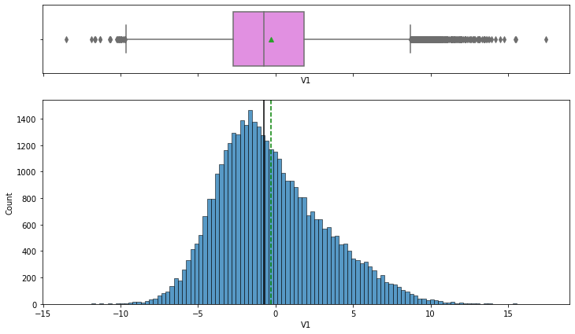

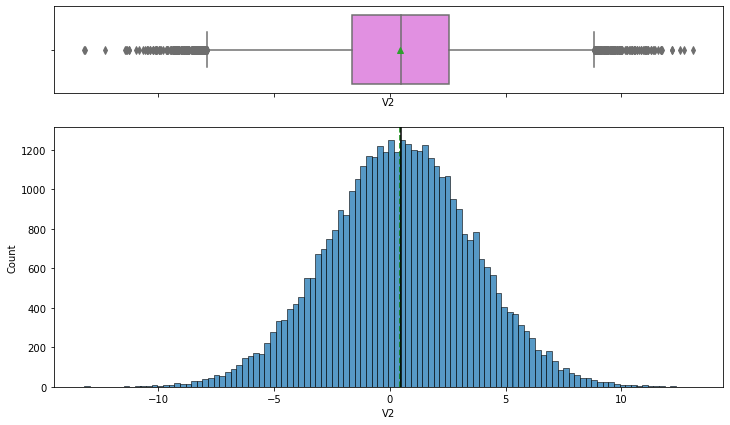

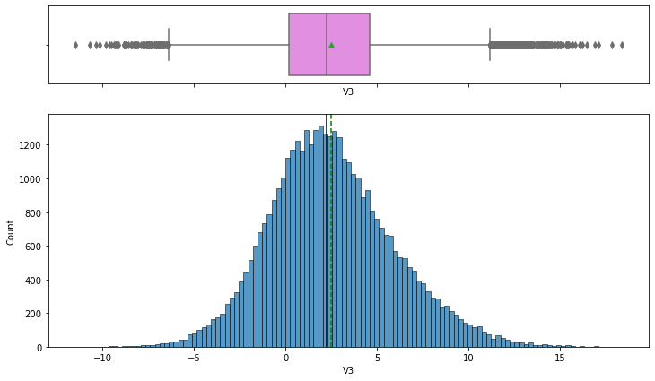

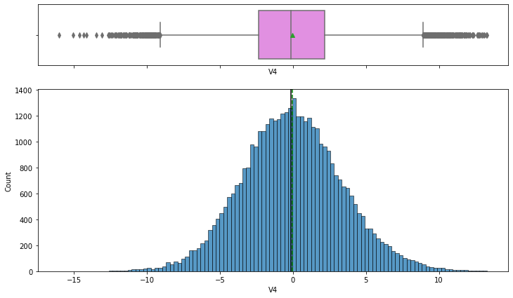

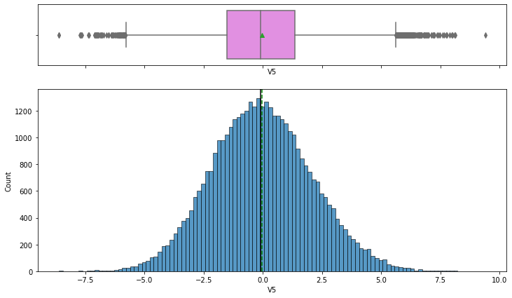

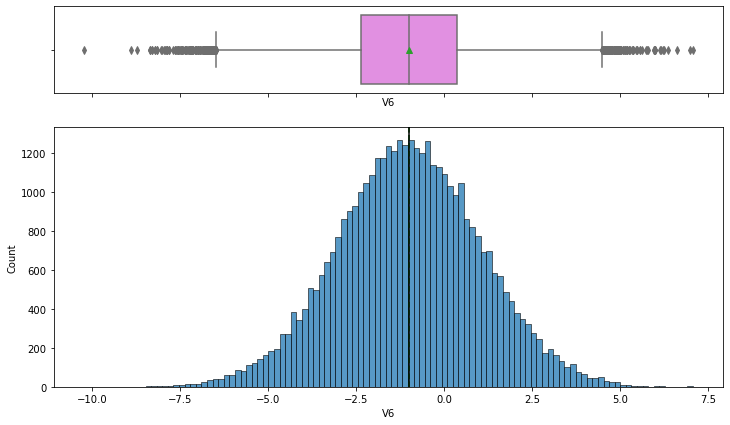

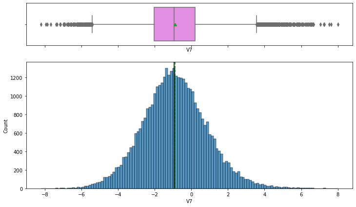

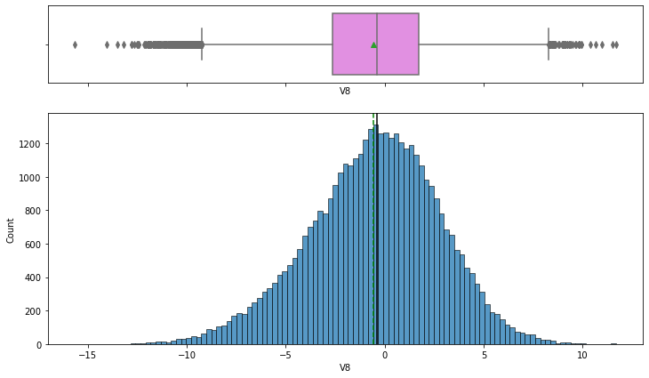

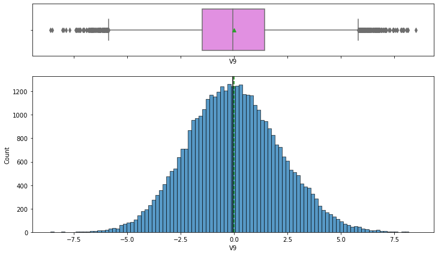

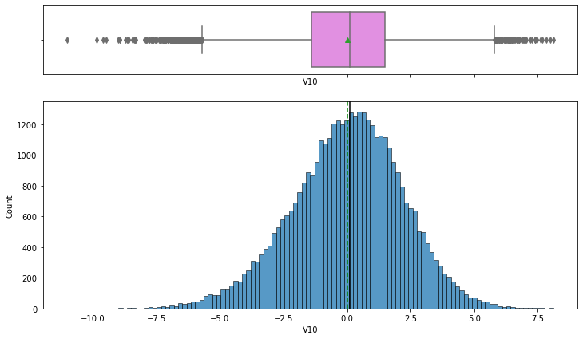

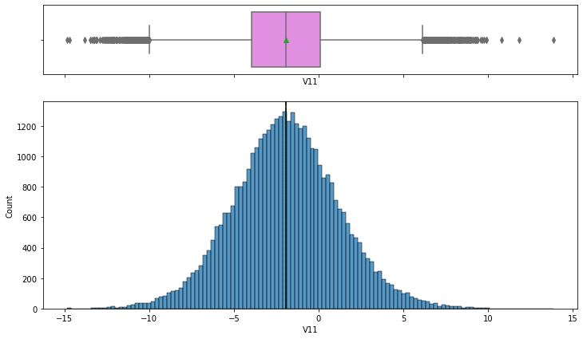

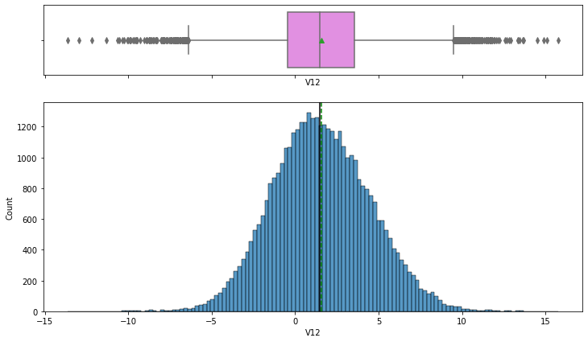

[28 more figures not shown]

```python
for feature in df_train.columns[df_train.dtypes=='float64']:
    histogram_boxplot(df_train, feature, figsize=(12, 7), kde=False, bins=None)
```

#### Observations

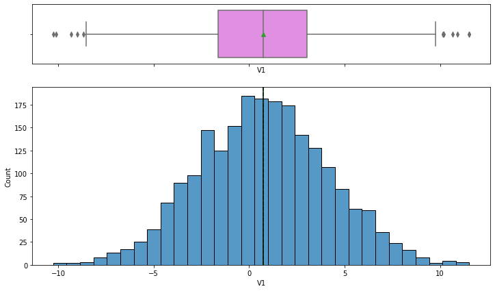

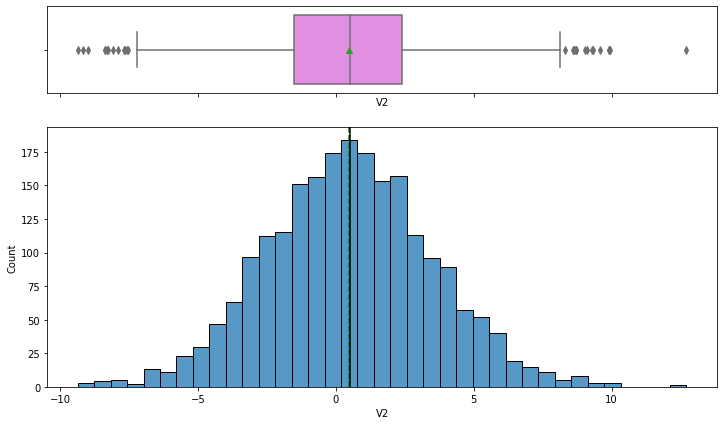

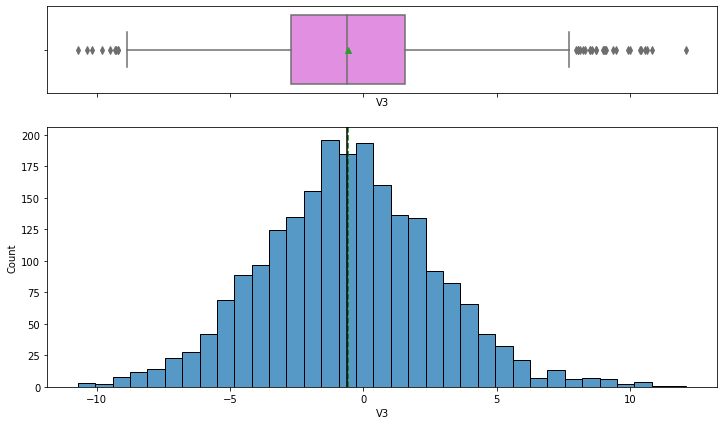

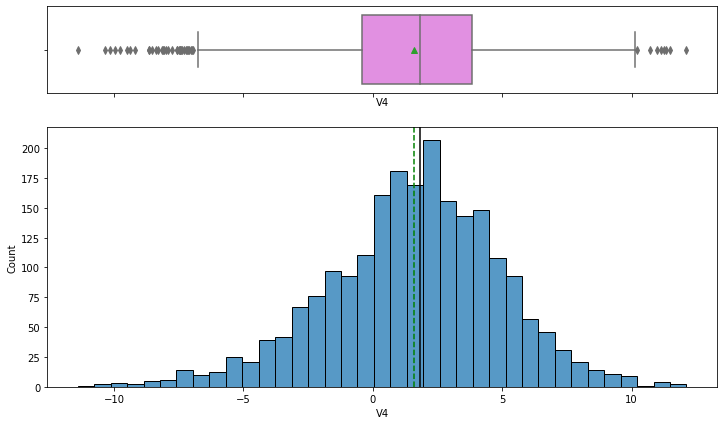

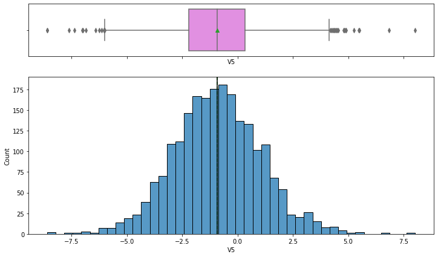

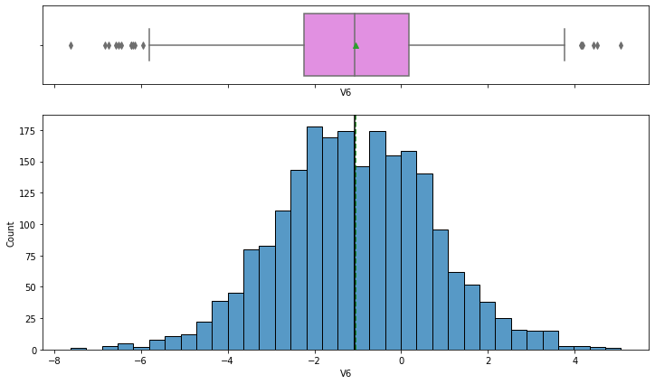

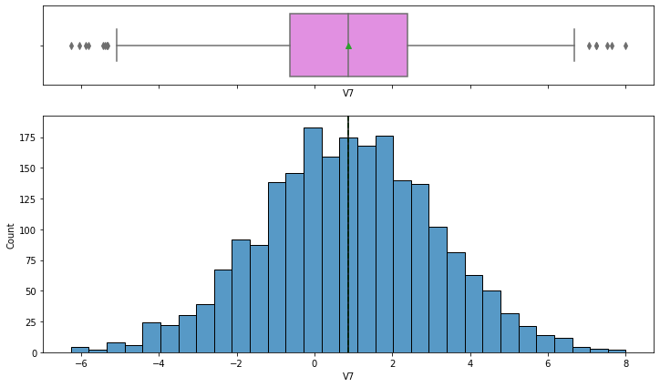

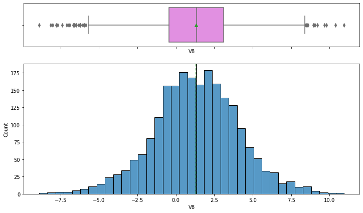

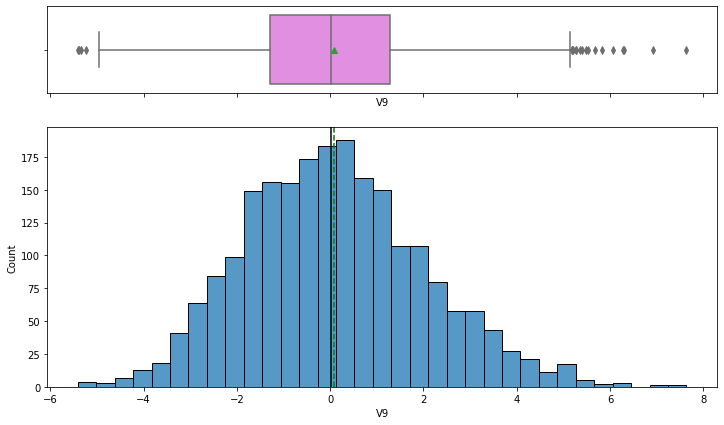

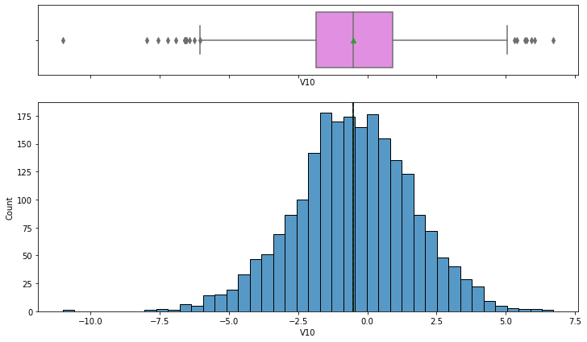

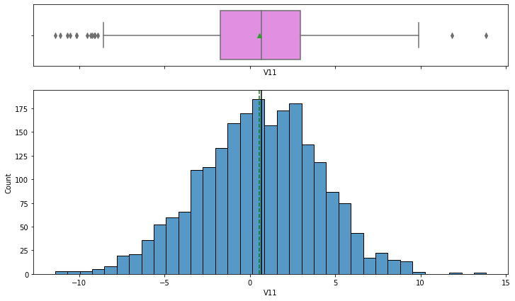

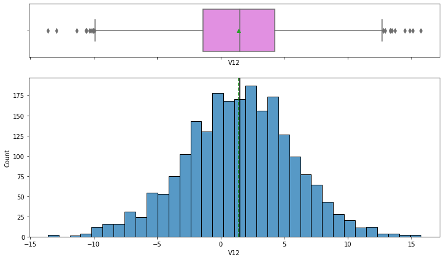

[28 more figures not shown]

```python
for feature in df_test.columns[df_test.dtypes=='float64']:
    histogram_boxplot(fail, feature, figsize=(12, 7), kde=False, bins=None)
```